# Italy Upper-Secondary Repetition and Bocciatura Pressure

## *Per consultare l'intero catalogo tracciabile dei 66 domini con reindirizzamento cella per cella, apri il documento master del repository: `local_data/processed/CATALOGO_COMPLETO_LINK_DIRETTI_66_DOMINI_PROOF_OF_DATA.md`*

## Methodological Scope

Source used here:

- ISTAT SDMX flow `52_1044_DF_DCIS_SCUOLE_15` (`Secondaria II grado - ripetenti per anno di corso`)

Important limitation:

- This is **not** a direct `promossi/bocciati` administrative dataset.
- It is an official updated dataset on `ripetenti`, which is the strongest currently available official proxy for school failure pressure in the upper-secondary system.
- The checked ISTAT upper-secondary indicator flow does not expose a direct `promossi/bocciati` variable, and the MIM SNV outcome files currently online are much older.

Interpretation rule used in this notebook:

- `TIME_PERIOD = 2024` is interpreted as proxy year `2024/2025`.

```python
from pathlib import Path
import pandas as pd
import numpy as np
import matplotlib.pyplot as plt
import seaborn as sns

sns.set_theme(style='whitegrid', context='talk')
pd.set_option('display.max_columns', 50)
pd.set_option('display.width', 140)

ROOT = Path.cwd()
if ROOT.name == 'Notebooks':
    ROOT = ROOT.parent

LONG_PATH = ROOT / 'local_data' / 'ISTAT' / 'school_outcomes' / 'istat_repeaters_upper_secondary_long.csv'
LATEST_PATH = ROOT / 'local_data' / 'processed' / 'istat_repeaters_upper_secondary_latest.csv'
RANKING_PATH = ROOT / 'local_data' / 'processed' / 'istat_repeaters_upper_secondary_ranking.csv'
MANIFEST_PATH = ROOT / 'local_data' / 'processed' / 'istat_school_outcomes_sources_manifest.csv'

repeaters = pd.read_csv(LONG_PATH)
latest = pd.read_csv(LATEST_PATH)
ranking = pd.read_csv(RANKING_PATH)
manifest = pd.read_csv(MANIFEST_PATH)

repeaters['TIME_PERIOD'] = pd.to_numeric(repeaters['TIME_PERIOD'], errors='coerce')
repeaters['OBS_VALUE'] = pd.to_numeric(repeaters['OBS_VALUE'], errors='coerce')
latest['TIME_PERIOD'] = pd.to_numeric(latest['TIME_PERIOD'], errors='coerce')
latest['repeaters'] = pd.to_numeric(latest['repeaters'], errors='coerce')
ranking['TIME_PERIOD'] = pd.to_numeric(ranking['TIME_PERIOD'], errors='coerce')
ranking['repeaters'] = pd.to_numeric(ranking['repeaters'], errors='coerce')

TYPE_LABELS = {
    'ALL': 'All upper secondary',
    'LIC': 'Licei',
    'TEC': 'Technical institutes',
    'VOC': 'Vocational institutes'
}
SEX_LABELS = {'F': 'Girls', 'M': 'Boys', 'T': 'Total'}
COURSE_YEAR_LABELS = {
    'ALL': 'All years',
    'FIR': 'First year',
    'SEC': 'Second year',
    'THIR': 'Third year and later'
}

def classify_territory_level(code):
    code = str(code)
    if code == 'IT':
        return 'national'
    if len(code) == 3:
        return 'macroarea'
    if len(code) == 4:
        return 'region'
    if len(code) == 5:
        return 'province_like'
    return 'other'

repeaters['type_label'] = repeaters['TYPE_SCHOOL'].map(TYPE_LABELS).fillna(repeaters['TYPE_SCHOOL'])
repeaters['sex_label'] = repeaters['SEX'].map(SEX_LABELS).fillna(repeaters['SEX'])
repeaters['course_year_label'] = repeaters['SCHOOL_YEAR'].map(COURSE_YEAR_LABELS).fillna(repeaters['SCHOOL_YEAR'])
repeaters['territory_level'] = repeaters['REF_AREA'].map(classify_territory_level)

latest_year = int(repeaters['TIME_PERIOD'].max())
latest_proxy = repeaters.loc[repeaters['TIME_PERIOD'] == latest_year, 'SCHOOL_YEAR_PROXY'].dropna().iloc[0]

print('Rows loaded:', len(repeaters))
print('Latest period:', latest_year, '=>', latest_proxy)
```

```
Rows loaded: 54740
Latest period: 2024 => 2024/2025
```

```python
manifest
```

|  | source | flow_id | flow_title_it | endpoint | min_time_period | max_time_period | max_school_year_proxy | has_time_period_2025 | checked_indicator_flow_id | checked_indicator_flow_title_it | indicator_data_types | indicator_data_type_labels | has_direct_promossi_or_bocciati | note |
| --- | --- | --- | --- | --- | --- | --- | --- | --- | --- | --- | --- | --- | --- | --- |
| 0 | ISTAT SDMX | 52_1044_DF_DCIS_SCUOLE_15 | Secondaria II grado - ripetenti per anno di corso | https://esploradati.istat.it/SDMXWS/rest/data/... | 2015 | 2024 | 2024/2025 | False | 52_1044_DF_DCIS_SCUOLE_13 | Secondaria II grado - indicatori scolastici | DISAB \| ENROL \| FEM \| FOR \| PUB | iscritti disabili per 1000 iscritti \| iscritti... | False | No direct promossi/bocciati variable found in ... |

## Prepare the Main Analysis Views

To keep the comparisons interpretable, most charts below use total sex, total citizenship, all management types together, and all course years together.

```python
base = repeaters[
    (repeaters['SEX'] == 'T')
    & (repeaters['CITIZENSHIP'] == 'TOTAL')
    & (repeaters['TYPE_SCHOOL_MANAGEMENT'] == 'ALL')
].copy()

national_by_type = base[(base['REF_AREA'] == 'IT') & (base['SCHOOL_YEAR'] == 'ALL')].copy()
latest_national_by_type = national_by_type[national_by_type['TIME_PERIOD'] == latest_year].copy()
latest_national_by_type = latest_national_by_type[['TYPE_SCHOOL', 'type_label', 'OBS_VALUE', 'TIME_PERIOD', 'SCHOOL_YEAR_PROXY']]
latest_national_by_type = latest_national_by_type.sort_values('OBS_VALUE', ascending=False)

regional_latest = base[
    (base['TIME_PERIOD'] == latest_year)
    & (base['SCHOOL_YEAR'] == 'ALL')
    & (base['TYPE_SCHOOL'] == 'ALL')
    & (base['territory_level'] == 'region')
].copy()

territorial_latest_by_type = base[
    (base['TIME_PERIOD'] == latest_year)
    & (base['SCHOOL_YEAR'] == 'ALL')
    & (base['TYPE_SCHOOL'] != 'ALL')
    & (base['territory_level'].isin(['region', 'province_like']))
].copy()

latest_national_by_type
```

|  | TYPE_SCHOOL | type_label | OBS_VALUE | TIME_PERIOD | SCHOOL_YEAR_PROXY |
| --- | --- | --- | --- | --- | --- |
| 174 | VOC | Vocational institutes | 11.7 | 2024 | 2024/2025 |
| 169 | TEC | Technical institutes | 7.4 | 2024 | 2024/2025 |
| 159 | ALL | All upper secondary | 5.7 | 2024 | 2024/2025 |
| 164 | LIC | Licei | 2.7 | 2024 | 2024/2025 |

## 1. National Trend by School Type

The long-run trend shows how the tripartite system evolved over time. The 2021 break should be interpreted carefully because pandemic-era evaluation rules affected repetition.

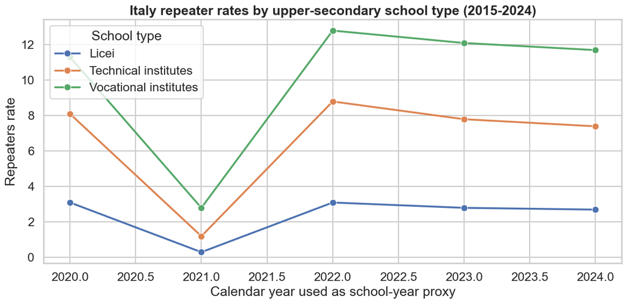

```python
trend = national_by_type[national_by_type['TYPE_SCHOOL'] != 'ALL'].copy()
fig, ax = plt.subplots(figsize=(12, 6))
sns.lineplot(data=trend, x='TIME_PERIOD', y='OBS_VALUE', hue='type_label', marker='o', linewidth=2.5, ax=ax)
ax.set_title('Italy repeater rates by upper-secondary school type (2015-2024)', fontweight='bold')
ax.set_xlabel('Calendar year used as school-year proxy')
ax.set_ylabel('Repeaters rate')
ax.legend(title='School type')
plt.tight_layout()
plt.show()
```

## 2. Latest Italy Snapshot

This view isolates the latest official situation and directly compares school tracks.

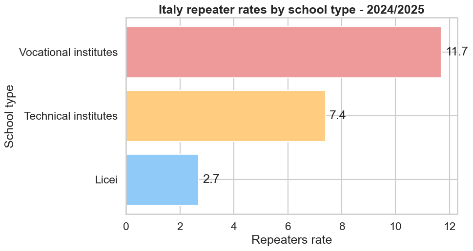

|  | TYPE_SCHOOL | type_label | repeaters_rate | TIME_PERIOD | SCHOOL_YEAR_PROXY | vs_total_gap |
| --- | --- | --- | --- | --- | --- | --- |
| 174 | VOC | Vocational institutes | 11.7 | 2024 | 2024/2025 | 6.0 |
| 169 | TEC | Technical institutes | 7.4 | 2024 | 2024/2025 | 1.7 |
| 159 | ALL | All upper secondary | 5.7 | 2024 | 2024/2025 | 0.0 |
| 164 | LIC | Licei | 2.7 | 2024 | 2024/2025 | -3.0 |

```python
snapshot = latest_national_by_type[latest_national_by_type['TYPE_SCHOOL'] != 'ALL'].copy()
snapshot = snapshot.sort_values('OBS_VALUE', ascending=True)
fig, ax = plt.subplots(figsize=(10, 5.5))
bars = ax.barh(snapshot['type_label'], snapshot['OBS_VALUE'], color=['#90caf9', '#ffcc80', '#ef9a9a'])
ax.set_title(f'Italy repeater rates by school type - {latest_proxy}', fontweight='bold')
ax.set_xlabel('Repeaters rate')
ax.set_ylabel('School type')
for bar in bars:
    width = bar.get_width()
    ax.text(width + 0.15, bar.get_y() + bar.get_height()/2, f'{width:.1f}', va='center')
plt.tight_layout()
plt.show()

snapshot_table = latest_national_by_type.copy().rename(columns={'OBS_VALUE': 'repeaters_rate'})
total_rate = snapshot_table.loc[snapshot_table['TYPE_SCHOOL'] == 'ALL', 'repeaters_rate'].iloc[0]
snapshot_table['vs_total_gap'] = snapshot_table['repeaters_rate'] - total_rate
snapshot_table
```

## 3. Gender and Course-Year Structure

These charts test whether repetition is generalized or concentrated in specific groups.

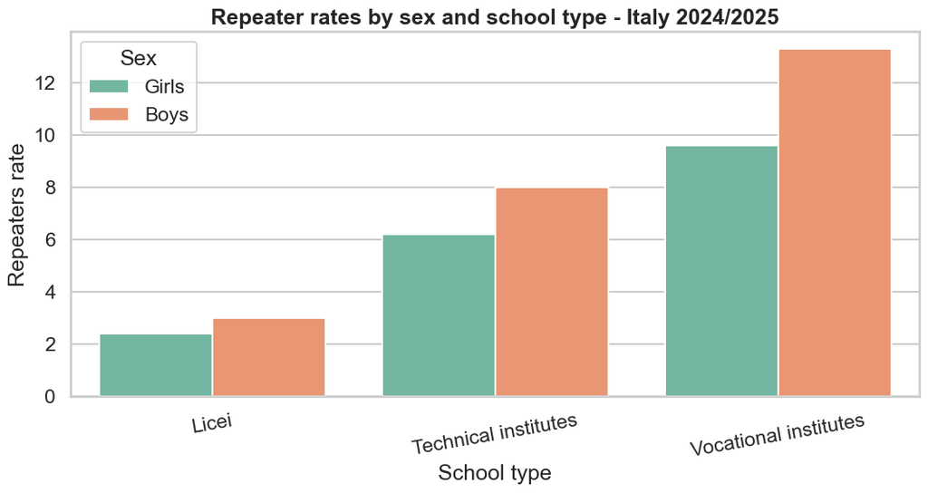

```python
sex_breakdown = repeaters[
    (repeaters['REF_AREA'] == 'IT')
    & (repeaters['TIME_PERIOD'] == latest_year)
    & (repeaters['TYPE_SCHOOL_MANAGEMENT'] == 'ALL')
    & (repeaters['CITIZENSHIP'] == 'TOTAL')
    & (repeaters['SCHOOL_YEAR'] == 'ALL')
    & (repeaters['TYPE_SCHOOL'] != 'ALL')
    & (repeaters['SEX'].isin(['F', 'M']))
].copy()

fig, ax = plt.subplots(figsize=(11, 6))
sns.barplot(data=sex_breakdown, x='type_label', y='OBS_VALUE', hue='sex_label', palette='Set2', ax=ax)
ax.set_title(f'Repeater rates by sex and school type - Italy {latest_proxy}', fontweight='bold')
ax.set_xlabel('School type')
ax.set_ylabel('Repeaters rate')
ax.legend(title='Sex')
plt.xticks(rotation=10)
plt.tight_layout()
plt.show()
```

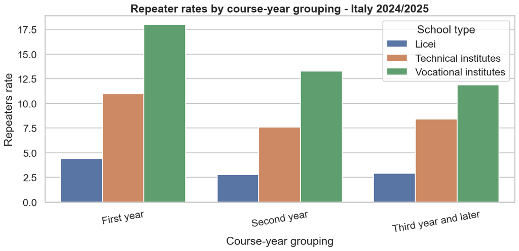

|  | type_label | course_year_label | OBS_VALUE |
| --- | --- | --- | --- |
| 189 | Licei | First year | 4.4 |
| 239 | Licei | Third year and later | 2.9 |
| 214 | Licei | Second year | 2.8 |
| 194 | Technical institutes | First year | 11.0 |
| 244 | Technical institutes | Third year and later | 8.4 |
| 219 | Technical institutes | Second year | 7.6 |
| 199 | Vocational institutes | First year | 18.0 |
| 224 | Vocational institutes | Second year | 13.3 |
| 249 | Vocational institutes | Third year and later | 11.9 |

```python
course_breakdown = repeaters[
    (repeaters['REF_AREA'] == 'IT')
    & (repeaters['TIME_PERIOD'] == latest_year)
    & (repeaters['SEX'] == 'T')
    & (repeaters['CITIZENSHIP'] == 'TOTAL')
    & (repeaters['TYPE_SCHOOL_MANAGEMENT'] == 'ALL')
    & (repeaters['TYPE_SCHOOL'] != 'ALL')
    & (repeaters['SCHOOL_YEAR'] != 'ALL')
].copy()

fig, ax = plt.subplots(figsize=(12, 6))
sns.barplot(data=course_breakdown, x='course_year_label', y='OBS_VALUE', hue='type_label', ax=ax)
ax.set_title(f'Repeater rates by course-year grouping - Italy {latest_proxy}', fontweight='bold')
ax.set_xlabel('Course-year grouping')
ax.set_ylabel('Repeaters rate')
ax.legend(title='School type')
plt.xticks(rotation=10)
plt.tight_layout()
plt.show()

course_breakdown[['type_label', 'course_year_label', 'OBS_VALUE']].sort_values(['type_label', 'OBS_VALUE'], ascending=[True, False])
```

## 4. Regional Geography

The regional view is the cleanest territorial comparison before moving down to more local hotspots.

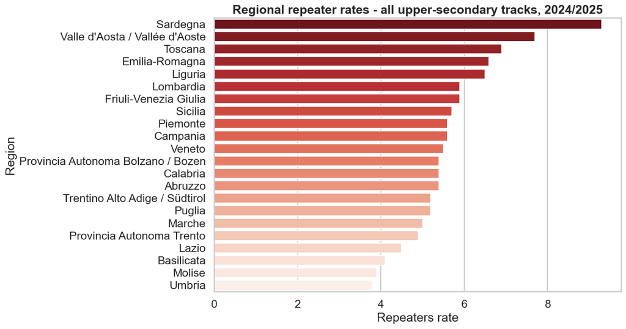

|  | REF_AREA_LABEL | repeaters_rate |
| --- | --- | --- |
| 0 | Sardegna | 9.3 |
| 1 | Valle d'Aosta / Vallée d'Aoste | 7.7 |
| 2 | Toscana | 6.9 |
| 3 | Emilia-Romagna | 6.6 |
| 4 | Liguria | 6.5 |
| 5 | Lombardia | 5.9 |
| 6 | Friuli-Venezia Giulia | 5.9 |
| 7 | Sicilia | 5.7 |
| 8 | Piemonte | 5.6 |
| 9 | Campania | 5.6 |

```python
regional_chart = regional_latest.sort_values('OBS_VALUE', ascending=False).copy()
fig, ax = plt.subplots(figsize=(13, 7))
sns.barplot(data=regional_chart, y='REF_AREA_LABEL', x='OBS_VALUE', hue='REF_AREA_LABEL', palette='Reds_r', dodge=False, legend=False, ax=ax)
ax.set_title(f'Regional repeater rates - all upper-secondary tracks, {latest_proxy}', fontweight='bold')
ax.set_xlabel('Repeaters rate')
ax.set_ylabel('Region')
plt.tight_layout()
plt.show()

regional_table = regional_chart[['REF_AREA_LABEL', 'OBS_VALUE']].rename(columns={'OBS_VALUE': 'repeaters_rate'}).reset_index(drop=True)
regional_table.head(10)
```

## 5. Top Hotspots by School Type

This section identifies the strongest local concentrations of repeaters within each track.

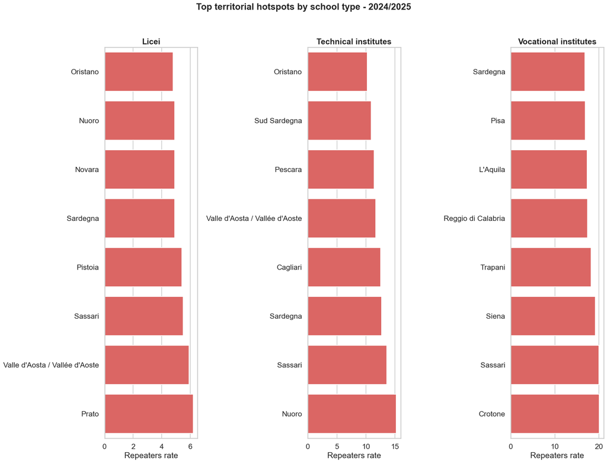

|  | type_label | REF_AREA_LABEL | repeaters_rate |
| --- | --- | --- | --- |
| 27273 | Licei | Prato | 6.2 |
| 6252 | Licei | Valle d'Aosta / Vallée d'Aoste | 5.9 |
| 53125 | Licei | Sassari | 5.5 |
| 26463 | Licei | Pistoia | 5.4 |
| 4676 | Licei | Novara | 4.9 |
| 52705 | Licei | Sardegna | 4.9 |
| 53523 | Licei | Nuoro | 4.9 |
| 54255 | Licei | Oristano | 4.8 |
| 53528 | Technical institutes | Nuoro | 15.2 |
| 53130 | Technical institutes | Sassari | 13.6 |
| 52710 | Technical institutes | Sardegna | 12.7 |
| 53896 | Technical institutes | Cagliari | 12.5 |
| 6257 | Technical institutes | Valle d'Aosta / Vallée d'Aoste | 11.7 |
| 37199 | Technical institutes | Pescara | 11.4 |
| 1882 | Technical institutes | Sud Sardegna | 10.9 |
| 54260 | Technical institutes | Oristano | 10.2 |
| 46300 | Vocational institutes | Crotone | 20.1 |
| 53135 | Vocational institutes | Sassari | 20.0 |
| 28866 | Vocational institutes | Siena | 19.2 |
| 48801 | Vocational institutes | Trapani | 18.2 |
| 47471 | Vocational institutes | Reggio di Calabria | 17.4 |
| 36436 | Vocational institutes | L'Aquila | 17.3 |
| 28093 | Vocational institutes | Pisa | 16.9 |
| 52715 | Vocational institutes | Sardegna | 16.8 |

```python
top_by_type = (
    territorial_latest_by_type
    .sort_values(['TYPE_SCHOOL', 'OBS_VALUE'], ascending=[True, False])
    .groupby('TYPE_SCHOOL', group_keys=False)
    .head(8)
    .copy()
)

fig, axes = plt.subplots(1, 3, figsize=(19, 14), sharex=False)
for ax, school_type in zip(axes, ['LIC', 'TEC', 'VOC']):
    sub = top_by_type[top_by_type['TYPE_SCHOOL'] == school_type].sort_values('OBS_VALUE', ascending=True)
    sns.barplot(data=sub, y='REF_AREA_LABEL', x='OBS_VALUE', color='#ef5350', ax=ax)
    ax.set_title(TYPE_LABELS[school_type], fontweight='bold')
    ax.set_xlabel('Repeaters rate')
    ax.set_ylabel('')
plt.suptitle(f'Top territorial hotspots by school type - {latest_proxy}', y=1.02, fontsize=20, fontweight='bold')
plt.tight_layout()
plt.show()

top_by_type[['type_label', 'REF_AREA_LABEL', 'OBS_VALUE']].rename(columns={'OBS_VALUE': 'repeaters_rate'})
```

## 6. Tripartite Inequality Across Regions

The heatmap below compares regional repeater pressure separately for licei, tecnici, and professionali. The final table quantifies the gap between vocational and liceo repetition pressure.

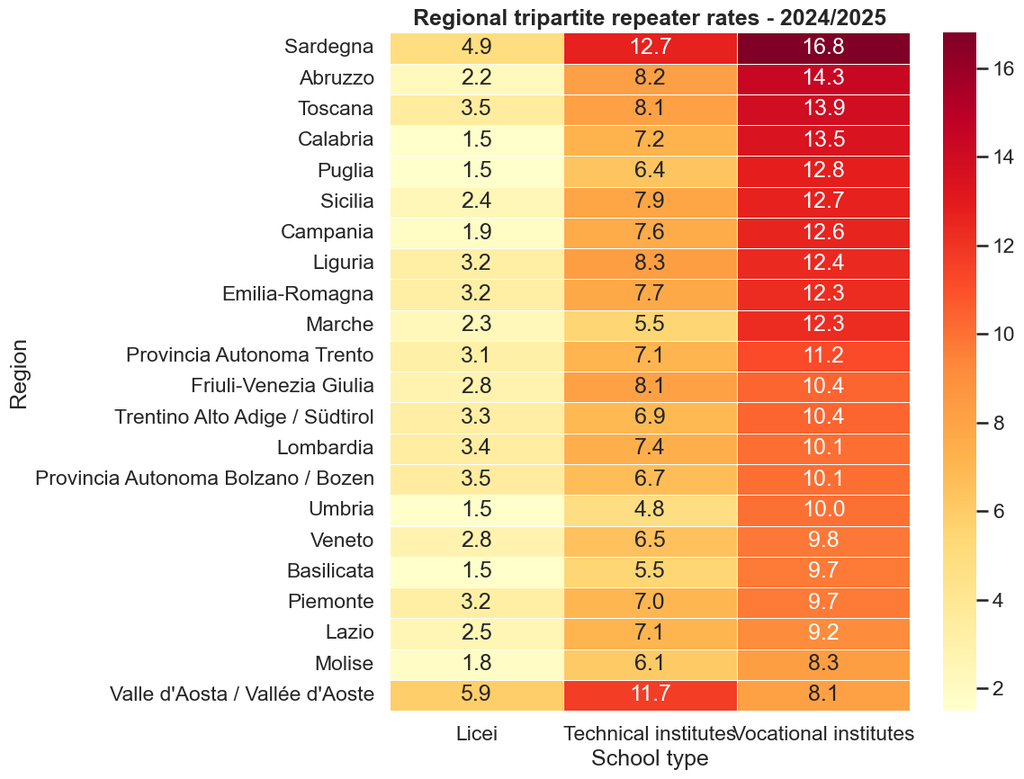

| type_label | REF_AREA_LABEL | Licei | Technical institutes | Vocational institutes | voc_minus_licei | tec_minus_licei |
| --- | --- | --- | --- | --- | --- | --- |
| 1 | Abruzzo | 2.2 | 8.2 | 14.3 | 12.1 | 6.0 |
| 3 | Calabria | 1.5 | 7.2 | 13.5 | 12.0 | 5.7 |
| 0 | Sardegna | 4.9 | 12.7 | 16.8 | 11.9 | 7.8 |
| 4 | Puglia | 1.5 | 6.4 | 12.8 | 11.3 | 4.9 |
| 6 | Campania | 1.9 | 7.6 | 12.6 | 10.7 | 5.7 |
| 2 | Toscana | 3.5 | 8.1 | 13.9 | 10.4 | 4.6 |
| 5 | Sicilia | 2.4 | 7.9 | 12.7 | 10.3 | 5.5 |
| 9 | Marche | 2.3 | 5.5 | 12.3 | 10.0 | 3.2 |
| 7 | Liguria | 3.2 | 8.3 | 12.4 | 9.2 | 5.1 |
| 8 | Emilia-Romagna | 3.2 | 7.7 | 12.3 | 9.1 | 4.5 |

```python
regional_type_matrix = territorial_latest_by_type[territorial_latest_by_type['territory_level'] == 'region'].copy()
regional_type_matrix = regional_type_matrix.pivot_table(index='REF_AREA_LABEL', columns='type_label', values='OBS_VALUE')
regional_type_matrix = regional_type_matrix.sort_values('Vocational institutes', ascending=False)

fig, ax = plt.subplots(figsize=(12, 9))
sns.heatmap(regional_type_matrix, annot=True, fmt='.1f', cmap='YlOrRd', linewidths=0.5, ax=ax)
ax.set_title(f'Regional tripartite repeater rates - {latest_proxy}', fontweight='bold')
ax.set_xlabel('School type')
ax.set_ylabel('Region')
plt.tight_layout()
plt.show()

regional_gap = regional_type_matrix.reset_index().copy()
regional_gap['voc_minus_licei'] = regional_gap['Vocational institutes'] - regional_gap['Licei']
regional_gap['tec_minus_licei'] = regional_gap['Technical institutes'] - regional_gap['Licei']
regional_gap.sort_values('voc_minus_licei', ascending=False).head(10)
```

## 7. Automated Findings

The final cell computes the main conclusions directly from the current data refresh.

```python
latest_tracks = latest_national_by_type[latest_national_by_type['TYPE_SCHOOL'] != 'ALL'].copy()
highest_track = latest_tracks.sort_values('OBS_VALUE', ascending=False).iloc[0]
lowest_track = latest_tracks.sort_values('OBS_VALUE', ascending=True).iloc[0]
ratio = highest_track['OBS_VALUE'] / lowest_track['OBS_VALUE']

trend_prev = national_by_type[(national_by_type['TIME_PERIOD'] == latest_year - 1) & (national_by_type['TYPE_SCHOOL'] != 'ALL')][['TYPE_SCHOOL', 'OBS_VALUE']].rename(columns={'OBS_VALUE': 'prev'})
trend_curr = latest_tracks[['TYPE_SCHOOL', 'type_label', 'OBS_VALUE']].rename(columns={'OBS_VALUE': 'curr'})
changes = trend_curr.merge(trend_prev, on='TYPE_SCHOOL', how='left')
changes['change'] = changes['curr'] - changes['prev']

top_region = regional_chart.iloc[0]
bottom_region = regional_chart.iloc[-1]
top_vocational = top_by_type[top_by_type['TYPE_SCHOOL'] == 'VOC'][['REF_AREA_LABEL', 'OBS_VALUE']].head(5).copy()

highest_label = highest_track['type_label']
highest_value = float(highest_track['OBS_VALUE'])
lowest_label = lowest_track['type_label']
lowest_value = float(lowest_track['OBS_VALUE'])
top_region_name = top_region['REF_AREA_LABEL']
top_region_value = float(top_region['OBS_VALUE'])
bottom_region_name = bottom_region['REF_AREA_LABEL']
bottom_region_value = float(bottom_region['OBS_VALUE'])

print(f'Latest proxy year: {latest_proxy}')
print()
print('Key findings')
print(f'- Highest national repeater pressure: {highest_label} ({highest_value:.1f})')
print(f'- Lowest national repeater pressure: {lowest_label} ({lowest_value:.1f})')
print(f'- Highest/lowest track ratio: {ratio:.2f}x')
print(f'- Highest regional overall rate: {top_region_name} ({top_region_value:.1f})')
print(f'- Lowest regional overall rate: {bottom_region_name} ({bottom_region_value:.1f})')
print()
print('Year-on-year movement by school type')
for row in changes.sort_values('curr', ascending=False).itertuples():
    direction = 'down' if row.change < 0 else 'up'
    print(f'- {row.type_label}: {row.curr:.1f} ({direction} {abs(row.change):.1f} vs previous year)')
print()
print('Top vocational hotspots')
print(top_vocational.rename(columns={'OBS_VALUE': 'repeaters_rate'}).to_string(index=False))
```

```
Latest proxy year: 2024/2025

Key findings
- Highest national repeater pressure: Vocational institutes (11.7)
- Lowest national repeater pressure: Licei (2.7)
- Highest/lowest track ratio: 4.33x
- Highest regional overall rate: Sardegna (9.3)
- Lowest regional overall rate: Umbria (3.8)

Year-on-year movement by school type
- Vocational institutes: 11.7 (down 0.4 vs previous year)
- Technical institutes: 7.4 (down 0.4 vs previous year)
- Licei: 2.7 (down 0.1 vs previous year)

Top vocational hotspots
    REF_AREA_LABEL  repeaters_rate
           Crotone            20.1
           Sassari            20.0
             Siena            19.2
           Trapani            18.2
Reggio di Calabria            17.4
```

## Substantive Reading of the Situation

If the latest pattern remains stable after future updates, the main substantive interpretation is the following:

- The tripartite system is not only differentiated by orientation, but also by very unequal exposure to repetition pressure.
- `Professionali` appear to be the most fragile segment, followed by `tecnici`, while `licei` remain structurally more protected.
- The geography of repeaters is not uniform: some southern and island territories are strong hotspots, but the pattern is not reducible to a simple North-South divide because some central and northern provinces also show elevated values.
- A large `vocational minus licei` gap is a strong warning sign of segmented school trajectories inside the same regional system.